# Assignment 3

Bayesian Data Analysis and Models of Behavior

Wenjie Tu

Spring Semester 2022

$~$

### Part 1

Description:

*The data for part 1 represent the amounts that two groups of participants (A and B) are willing to pay for snack food items. Each individual places bids to buy 60 different food items. All participants saw the same 60 foods. They were given an endowment of 5 CHF per food item to use in purchasing the food items from the experimenter. Thus, the maximum bid was 5, even if the participant might have been willing to pay more than 5 CHF.*

```r
# Read in data for willingness to pay
d.wtp <- read.csv("./data/wtp_data.csv")
rmarkdown::paged_table(d.wtp)
```

| Subject | Group | Food | Bid |
| --- | --- | --- | --- |
| 1 | A | 1 | 2.19 |
| 1 | A | 2 | 4.42 |
| 1 | A | 3 | 5.00 |
| 1 | A | 4 | 0.48 |
| 1 | A | 5 | 4.64 |
| 1 | A | 6 | 4.76 |
| 1 | A | 7 | 3.14 |
| 1 | A | 8 | 3.18 |
| 1 | A | 9 | 3.15 |
| 1 | A | 10 | 2.66 |

[output cut: 2390 more lines]

```r
library(ggplot2)
library(GGally)
library(rjags)
library(runjags)
library(HDInterval)
```

#### Histogram and density plot

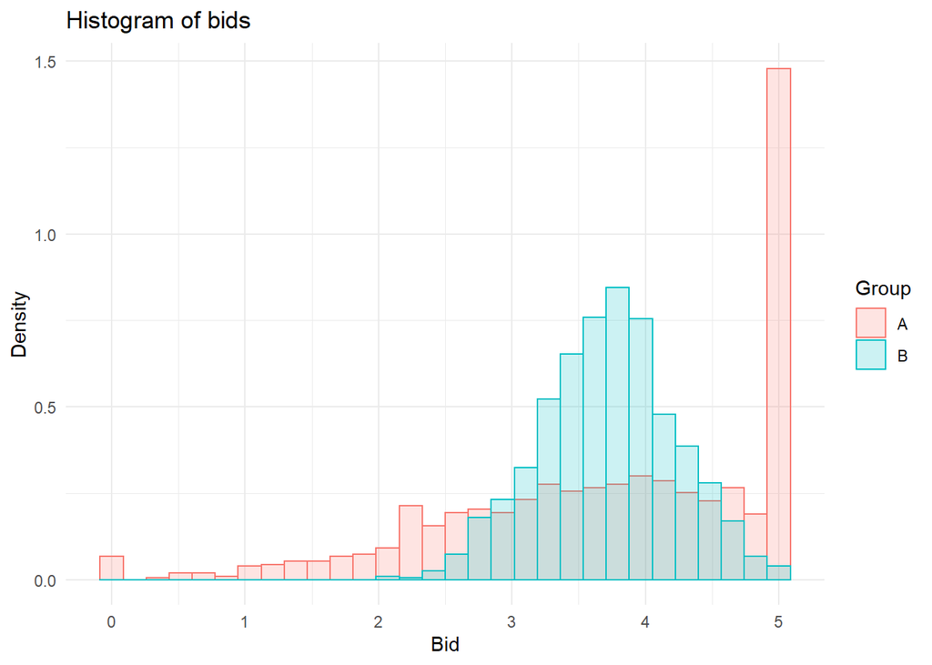

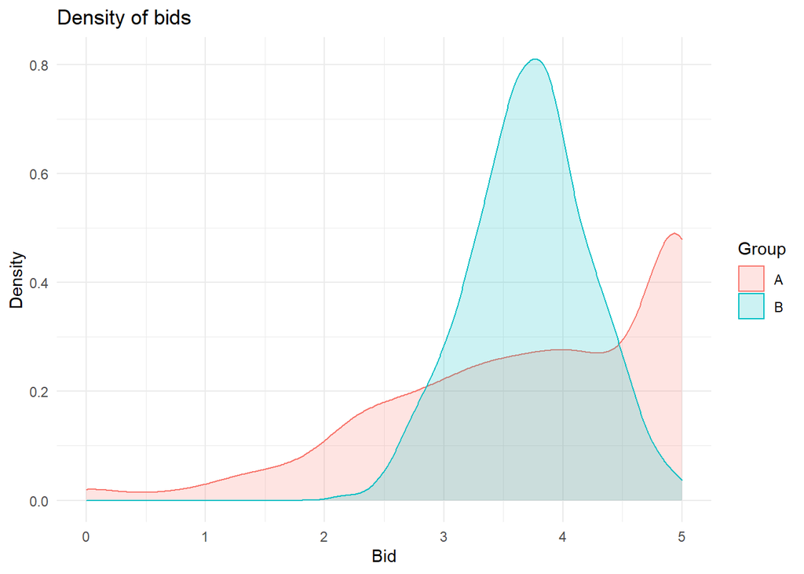

```r
ggplot(d.wtp, aes(x=Bid, y=..density.., color=Group, fill=Group)) +
  geom_histogram(position="identity", bins=30, alpha=0.2) +
  labs(title="Histogram of bids", y="Density") + theme_minimal()

ggplot(d.wtp, aes(x=Bid, y=..density.., color=Group, fill=Group)) +
  geom_density(alpha=0.2) + labs(title="Density of bids", y="Density") +
  theme_minimal()
```

#### Summary tables and correlation plots

```r
# Write in JAGS model
modelString <- "model{
  for (g in 1:Ngrps) {
    # group-specific priors
    grp.mu[g] ~ dnorm(0, 1.0E-5)
    grp.sig[g] ~ dunif(1.0E-6, 100)

    # prior for the standard deviation of the response
    sig[g] ~ dunif(1.0E-5, 100)

    for (s in 1:Nsubj[g]) {
      subj.mu[s, g] ~ dnorm(grp.mu[g], 1/grp.sig[g]^2)
    }
  }

  for (i in 1:Ntotal) {
    y[i] ~ dnorm(subj.mu[subIdx[i], grpIdx[i]], 1/sig[grpIdx[i]]^2)
  }
}"

writeLines(modelString, con="./models/StandardModel.txt")
```

```r
y <- d.wtp$Bid
Ntotal <- length(y)
subIdx <- d.wtp$Subject
grpIdx <- as.numeric(as.factor(d.wtp$Group))
Ngrps <- length(unique(d.wtp$Group))
Nsubj <- c(length(unique(d.wtp$Subject)), length(unique(d.wtp$Subject)))
```

```r
n.sample <- 2000
n.burnin <- 1000
n.thin <- 2
n.chains <- 3

dat.standard <- dump.format(list(y = y,
                                 Ntotal = Ntotal,
                                 subIdx = subIdx,
                                 grpIdx = grpIdx,
                                 Ngrps = Ngrps,
                                 Nsubj = Nsubj))

# Let JAGS initialize
inits1 <- dump.format(list(.RNG.name="base::Super-Duper", .RNG.seed=99999))
inits2 <- dump.format(list(.RNG.name="base::Wichmann-Hill", .RNG.seed=1234))
inits3 <- dump.format(list(.RNG.name="base::Mersenne-Twister", .RNG.seed=6666))

# Tell JAGS which latent variables to monitor
monitor = c("grp.mu", "grp.sig", "sig")
```

```r
results.standard <- run.jags(model = "./models/StandardModel.txt",
                             monitor = monitor,
                             data = dat.standard,
                             n.chains = n.chains,
                             inits = c(inits1, inits2, inits3),
                             plots = FALSE,
                             burnin = n.burnin,
                             sample = n.sample,
                             thin = n.thin)
```

```
## Compiling rjags model...
## Calling the simulation using the rjags method...
## Adapting the model for 1000 iterations...
## Burning in the model for 1000 iterations...
## Running the model for 4000 iterations...
## Simulation complete
## Calculating summary statistics...
## Calculating the Gelman-Rubin statistic for 6 variables....
## Finished running the simulation
```

```r
knitr::kable(summary(results.standard), align="c", caption="Summary results for the standard model")
```

Summary results for the standard model

|  | Lower95 | Median | Upper95 | Mean | SD | Mode | MCerr | MC%ofSD | SSeff | AC.20 | psrf |
| --- | --- | --- | --- | --- | --- | --- | --- | --- | --- | --- | --- |
| grp.mu[1] | 3.6643338 | 3.7475143 | 3.8329333 | 3.7467693 | 0.0430744 | NA | 0.0009642 | 2.2 | 1996 | 0.0206805 | 1.001637 |
| grp.mu[2] | 3.6854814 | 3.7188868 | 3.7523388 | 3.7193982 | 0.0170116 | NA | 0.0006991 | 4.1 | 592 | 0.1795134 | 1.002859 |
| grp.sig[1] | 0.0102595 | 0.1116116 | 0.2099225 | 0.1137392 | 0.0525471 | NA | 0.0023477 | 4.5 | 501 | 0.2258151 | 1.004847 |
| grp.sig[2] | 0.0000735 | 0.0262768 | 0.0630370 | 0.0285976 | 0.0193892 | NA | 0.0012582 | 6.5 | 237 | 0.4611961 | 1.007699 |
| sig[1] | 1.1149633 | 1.1641400 | 1.2084727 | 1.1646641 | 0.0240186 | NA | 0.0003263 | 1.4 | 5418 | -0.0103021 | 1.000794 |
| sig[2] | 0.4846711 | 0.5051570 | 0.5264808 | 0.5052667 | 0.0106460 | NA | 0.0001439 | 1.4 | 5475 | 0.0125783 | 1.000427 |

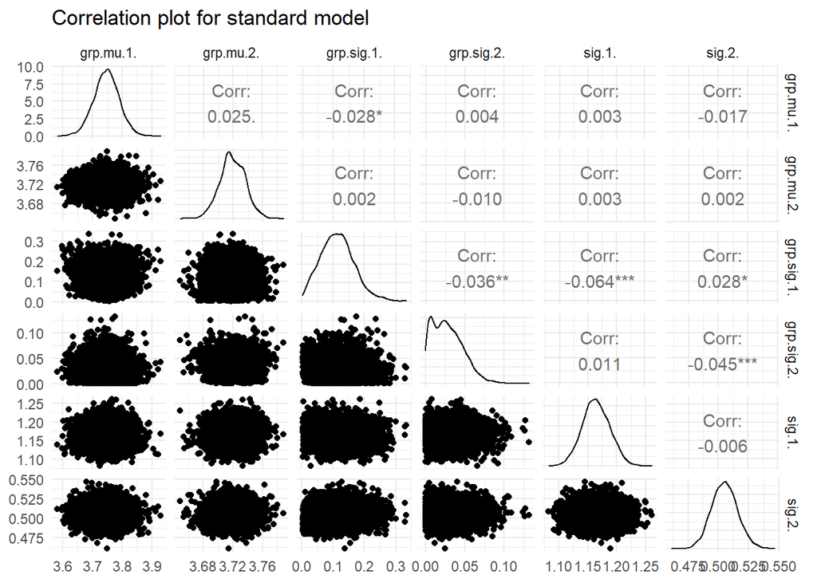

```r
chains.standard <- data.frame(rbind(results.standard[["mcmc"]][[1]],
                                    results.standard[["mcmc"]][[2]],
                                    results.standard[["mcmc"]][[3]]))
ggpairs(chains.standard, title="Correlation plot for standard model") + theme_minimal()
```

```r
# Write in JAGS model
modelString <- "model{
  for (g in 1:Ngrps) {
    # group-specific priors
    grp.mu[g] ~ dnorm(0, 1.0E-5)
    grp.sig[g] ~ dunif(1.0E-6, 100)

    # prior for the standard deviation of the response
    sig[g] ~ dunif(1.0E-5, 100)

    for (s in 1:Nsubj[g]) {
      subj.mu[s, g] ~ dnorm(grp.mu[g], 1/grp.sig[g]^2)
    }
  }

  for (i in 1:Ntotal) {
    y[i] ~ dnorm(subj.mu[subIdx[i], grpIdx[i]], 1/sig[grpIdx[i]]^2)
    ybin[i] ~ dinterval(y[i], threshMat[i, ])
  }
}"

writeLines(modelString, con="./models/CensoredModel.txt")
```

```r
y <- d.wtp$Bid
Ntotal <- length(y)
subIdx <- d.wtp$Subject
grpIdx <- as.numeric(as.factor(d.wtp$Group))
Ngrps <- length(unique(d.wtp$Group))
Nsubj <- rep(length(unique(d.wtp$Subject)), times=Ngrps)
```

```r
binThresholds <- c(min(y), max(y))
ybin <- y
for (i in 1:length(y)) {
  if (y[i] == binThresholds[1]) {
    ybin[i] = 0
  } else if (y[i] == binThresholds[2]){
    ybin[i] = 2
  } else{
    ybin[i] = 1
  }
}

y[ybin == 0] <- NA
y[ybin == 2] <- NA

threshMat <- matrix(rep(binThresholds, length(y)), byrow=TRUE, nrow=length(y),
                    dimnames=list(NULL, paste0("thresh",1:length(binThresholds))))

# initial values of censored data:
yInit <- rep(NA , length(y))
for (i in 1:length(y)) {
  # if y is censored
  if (is.na(y[i])) {
    # if it is from the lowest bin
    if (ybin[i] == 0) {
      # initialize at below the lower bound of threshold
      yInit[i] <- threshMat[i, 1] - 1
      # if it is from the highest bin
    } else if (ybin[i] == 2) {
      # initialize at above the upper bound of threshold
      yInit[i] <- threshMat[i, 2] + 1
    } else {
      # initialize at middle of bin
      yInit[i] <- (threshMat[i, ybin[i]] + threshMat[i, ybin[i] + 1]) / 2
    }
  }
}
```

```r
dat.censored <- dump.format(list(y = y,
                                 Ntotal = Ntotal,
                                 subIdx = subIdx,
                                 grpIdx = grpIdx,
                                 Ngrps = Ngrps,
                                 Nsubj = Nsubj,
                                 threshMat = threshMat,
                                 ybin = ybin))

inits1 <- dump.format(list(.RNG.name="base::Super-Duper", .RNG.seed=99999))
inits2 <- dump.format(list(.RNG.name="base::Wichmann-Hill", .RNG.seed=1234))
inits3 <- dump.format(list(.RNG.name="base::Mersenne-Twister", .RNG.seed=6666))

# Tell JAGS which latent variables to monitor
monitor = c("grp.mu", "grp.sig", "sig")
```

```r
results.censored <- run.jags(model = "./models/CensoredModel.txt",
                             monitor = monitor,
                             data = dat.censored,
                             n.chains = n.chains,
                             inits = c(inits1, inits2, inits3),
                             plots = FALSE,
                             burnin = n.burnin,
                             sample = n.sample,
                             thin = n.thin)
```

```
## Compiling rjags model...
## Calling the simulation using the rjags method...
## Adapting the model for 1000 iterations...
## Burning in the model for 1000 iterations...
## Running the model for 4000 iterations...
## Simulation complete
## Calculating summary statistics...
## Calculating the Gelman-Rubin statistic for 6 variables....
## Finished running the simulation
```

```r
knitr::kable(summary(results.censored), align="c", caption="Summary results for the censored model")
```

Summary results for the censored model

|  | Lower95 | Median | Upper95 | Mean | SD | Mode | MCerr | MC%ofSD | SSeff | AC.20 | psrf |
| --- | --- | --- | --- | --- | --- | --- | --- | --- | --- | --- | --- |
| grp.mu[1] | 3.8469580 | 3.9479165 | 4.0595766 | 3.9489758 | 0.0535479 | NA | 0.0013358 | 2.5 | 1607 | 0.0193494 | 1.0043716 |
| grp.mu[2] | 3.6851608 | 3.7185497 | 3.7473857 | 3.7187869 | 0.0159376 | NA | 0.0006538 | 4.1 | 594 | 0.1846761 | 1.0075262 |
| grp.sig[1] | 0.0012484 | 0.1206696 | 0.2395748 | 0.1237714 | 0.0676627 | NA | 0.0037974 | 5.6 | 317 | 0.3318470 | 1.0046897 |
| grp.sig[2] | 0.0001618 | 0.0249725 | 0.0633215 | 0.0280119 | 0.0194453 | NA | 0.0011943 | 6.1 | 265 | 0.4059735 | 1.0169655 |
| sig[1] | 1.4026036 | 1.4741242 | 1.5431247 | 1.4750567 | 0.0364873 | NA | 0.0006212 | 1.7 | 3450 | 0.0273024 | 1.0001064 |
| sig[2] | 0.4874418 | 0.5071311 | 0.5276976 | 0.5074181 | 0.0104176 | NA | 0.0001431 | 1.4 | 5299 | -0.0137722 | 0.9998306 |

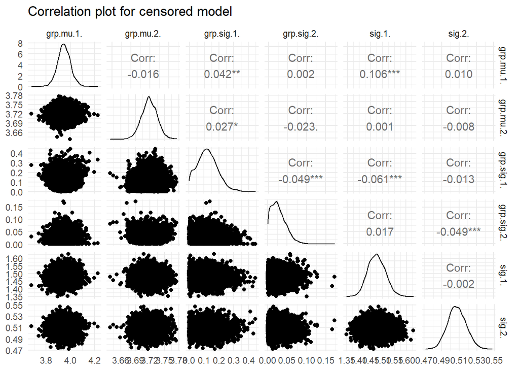

```r
chains.censored <- data.frame(rbind(results.censored[["mcmc"]][[1]],
                                    results.censored[["mcmc"]][[2]],
                                    results.censored[["mcmc"]][[3]]))
ggpairs(chains.censored, title="Correlation plot for censored model") + theme_minimal()
```

#### Empirical density based on estimates

```r
mu1.standard <- summary(results.standard)["grp.mu[1]", "Mean"]
mu2.standard <- summary(results.standard)["grp.mu[2]", "Mean"]
sig1.standard <- summary(results.standard)["grp.sig[1]", "Mean"]
sig2.standard <- summary(results.standard)["grp.sig[2]", "Mean"]
```

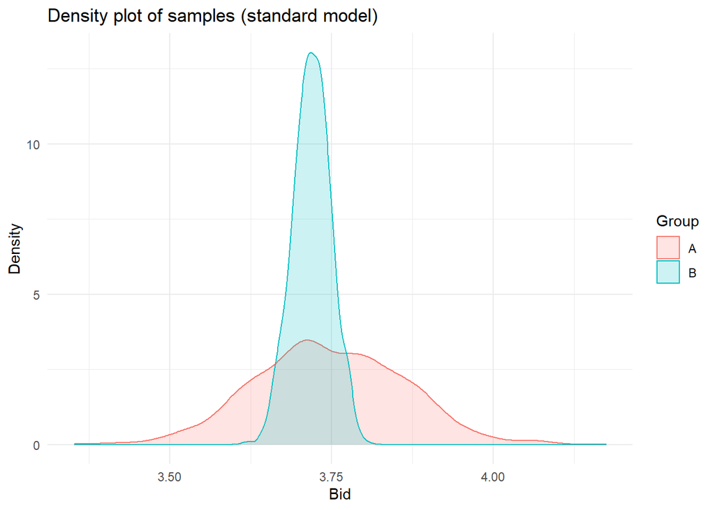

```r
# Set seed for reproducible results
set.seed(2022)

# Set sample size
M <- 1000

# Generate random samples using estimated parameters
group1.standard <- rnorm(M, mean=mu1.standard, sd=sig1.standard)
group2.standard <- rnorm(M, mean=mu2.standard, sd=sig2.standard)

# Create a dataframe for ggplot
d.plot <- data.frame(Bid=c(group1.standard, group2.standard),
                     Group=rep(c("A", "B"), each=M))

ggplot(d.plot, aes(x=Bid, y=..density.., color=Group, fill=Group)) +
  geom_density(alpha=0.2) + theme_minimal() +
  labs(title="Density plot of samples (standard model)", y="Density")
```

```r
mu1.censored <- summary(results.censored)["grp.mu[1]", "Mean"]
mu2.censored <- summary(results.censored)["grp.mu[2]", "Mean"]
sig1.censored <- summary(results.censored)["grp.sig[1]", "Mean"]
sig2.censored <- summary(results.censored)["grp.sig[2]", "Mean"]
```

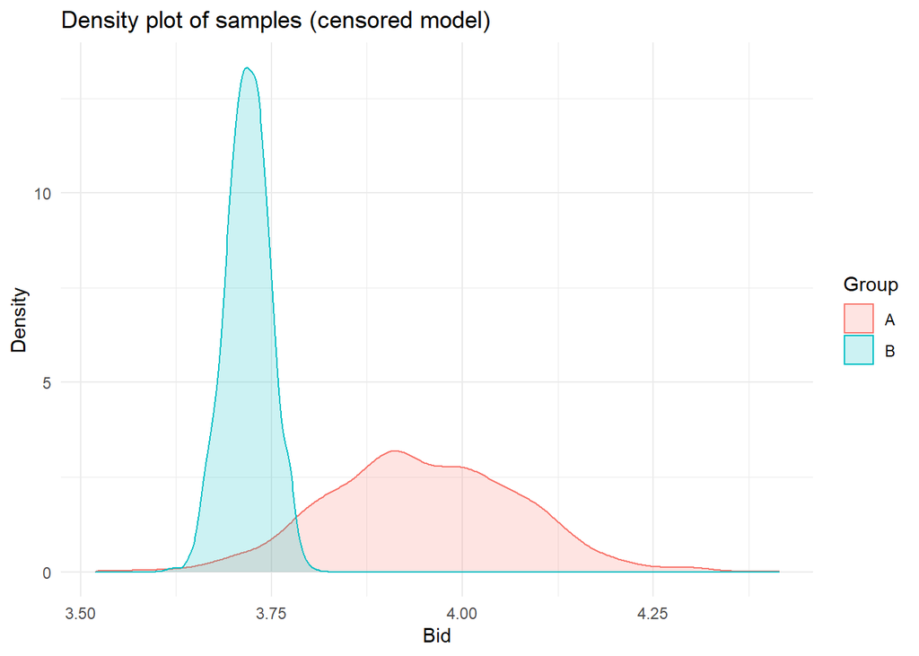

```r
# Set seed for reproducible results
set.seed(2022)
# Set sample size
M <- 1000

# Generate random samples using estimated parameters
group1.censored <- rnorm(M, mean=mu1.censored, sd=sig1.censored)
group2.censored <- rnorm(M, mean=mu2.censored, sd=sig2.censored)

# Create a dataframe for ggplot
d.plot <- data.frame(Bid=c(group1.censored, group2.censored),
                     Group=rep(c("A", "B"), each=M))

ggplot(d.plot, aes(x=Bid, y=..density.., color=Group, fill=Group)) +
  geom_density(alpha=0.2) + theme_minimal() +
  labs(title="Density plot of samples (censored model)", y="Density")
```

#### Contrasts

Contrasts are based on the difference between sample posterior distributions of parameters

```r
contrast.mu.std <- chains.standard[, "grp.mu.1."] - chains.standard[, "grp.mu.2."]
contrast.sig.std <- chains.standard[, "grp.sig.1."] - chains.standard[, "grp.sig.2."]

contrast.mu.csd <- chains.censored[, "grp.mu.1."] - chains.censored[, "grp.mu.2."]
contrast.sig.csd <- chains.censored[, "grp.sig.1."] - chains.censored[, "grp.sig.2."]
```

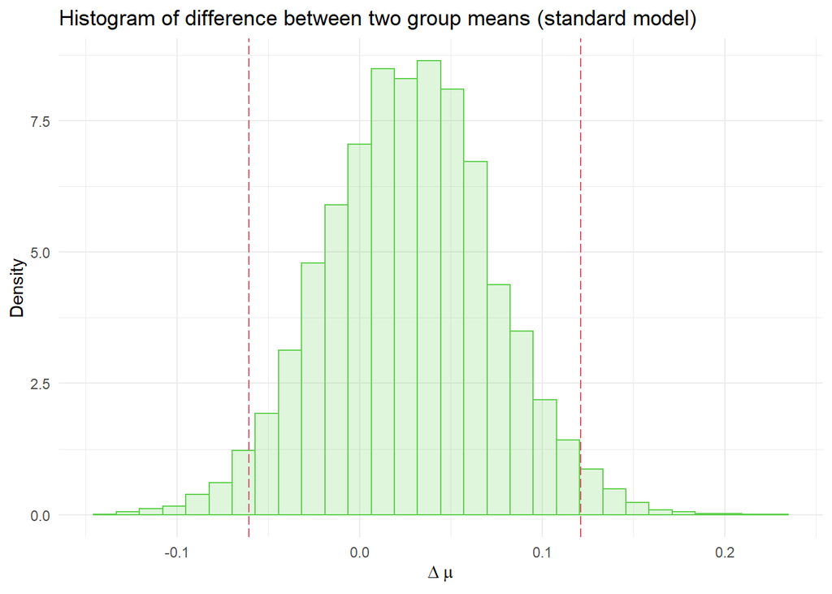

```r
ggplot(data.frame(x=contrast.mu.std), aes(x=x, y=..density..)) +
  geom_histogram(bins=30, alpha=0.2, color=3, fill=3) +
  geom_vline(xintercept=hdi(contrast.mu.std), color=2, lty="longdash") +
  labs(title="Histogram of difference between two group means (standard model)",
       x=expression(Delta~mu), y="Density") + theme_minimal()
```

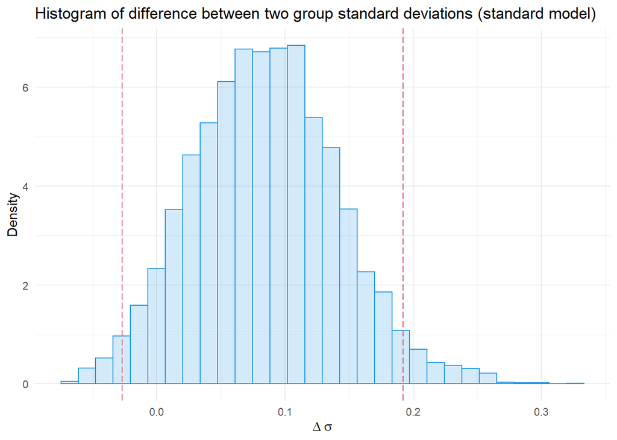

```r
ggplot(data.frame(x=contrast.sig.std), aes(x=x, y=..density..)) +
  geom_histogram(bins=30, alpha=0.2, color=4, fill=4) +
  geom_vline(xintercept=hdi(contrast.sig.std), color=2, lty="longdash") +
  labs(title="Histogram of difference between two group standard deviations (standard model)",
       x=expression(Delta~sigma), y="Density") + theme_minimal()
```

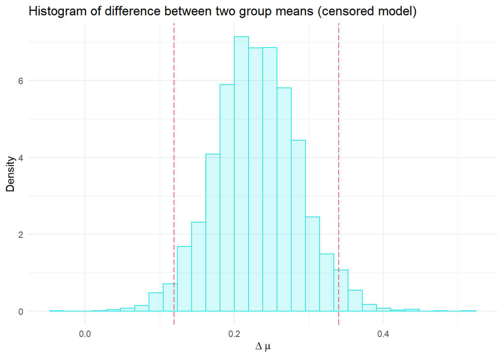

```r
ggplot(data.frame(x=contrast.mu.csd), aes(x=x, y=..density..)) +
  geom_histogram(bins=30, alpha=0.2, color=5, fill=5) +
  geom_vline(xintercept=hdi(contrast.mu.csd), color=2, lty="longdash") +
  labs(title="Histogram of difference between two group means (censored model)",
       x=expression(Delta~mu), y="Density") + theme_minimal()
```

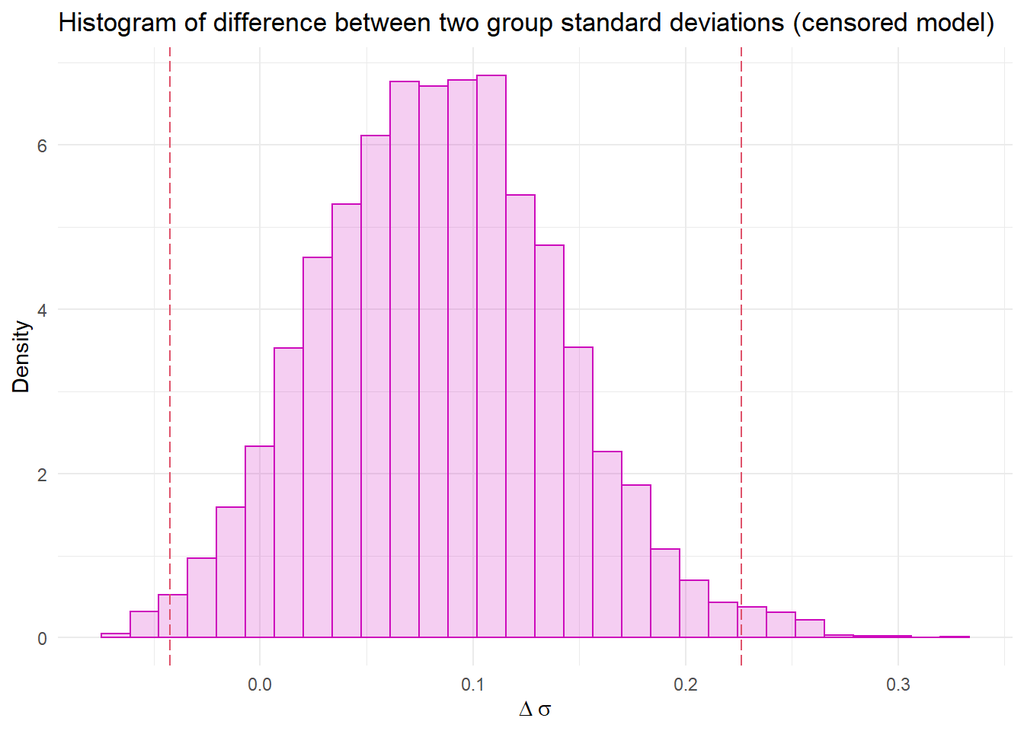

```r
ggplot(data.frame(x=contrast.sig.std), aes(x=x, y=..density..)) +
  geom_histogram(bins=30, alpha=0.2, color=6, fill=6) +
  geom_vline(xintercept=hdi(contrast.sig.csd), color=2, lty="longdash") +
  labs(title="Histogram of difference between two group standard deviations (censored model)",
       x=expression(Delta~sigma), y="Density") + theme_minimal()
```

We want to test whether group-level means and standard deviations differ across group A and group B in the standard normal model and censored normal model separately using 95% highest density intervals (HDIs).

$$\begin{aligned}
\mu_1 & \overset{?}{=}\mu_2 \\
\sigma_1& \overset{?}{=}\sigma_2
\end{aligned}$$

- For the standard model, we see that both $\Delta\mu=0$ and $\Delta\sigma$ lie in their 95% HDIs.
- For the censored model, we see that the 95% HDI for $\Delta\mu$ does not include $\Delta\mu=0$ while the 95% HDI for $\Delta\sigma$ includes $\Delta\sigma=0$.

We therefore conclude that with 95% HDIs both the group-level means and standard deviations do not differ in the standard normal model whereas the group-level means do differ but standard deviations do not differ in the censored normal model.

$~$

### Part 2

Description:

*The data for part 2 represent ratings on the desire to eat a food item a Likert scale (“Strong No”, “No”, “Neutral”, “Yes”, “Strong Yes”). These categorical responses are recorded as the numbers from -2 to 2 in the data file. There are groups of participants (A and B). Each individual rated 60 different food items in terms of the desire to eat on the Likert scale above, as well as two different attributes ($x_1$ and $x_2$) of the food items on a visual analog scale. We will assume that these visual analog ratings are continuous and censored by the endpoints of the scale. All participants saw the same 60 food items.*

$$\text{Rating}=\beta_0+\beta_1\cdot x_1+\beta_2\cdot x_2+\text{error}$$

```r
d.ratings <- read.csv("./data/ratings_data.csv")
d.ratings$Group <- factor(d.ratings$Group)
```

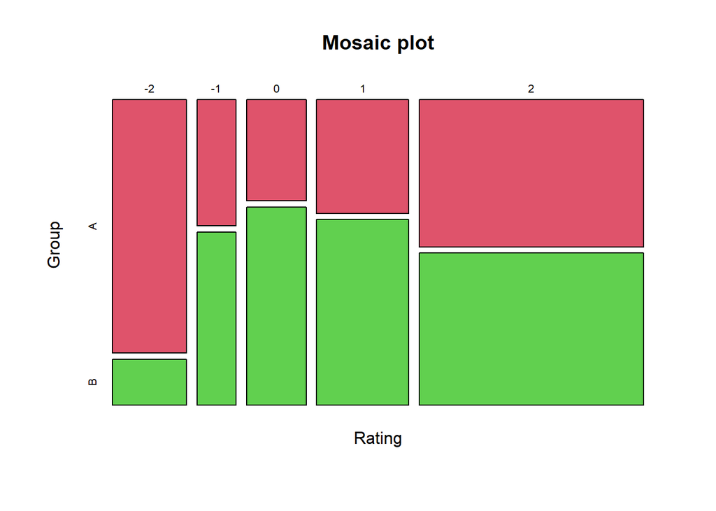

```r
mosaicplot(Rating ~ Group, data=d.ratings, col=2:3, main="Mosaic plot")
```

#### Bar plots

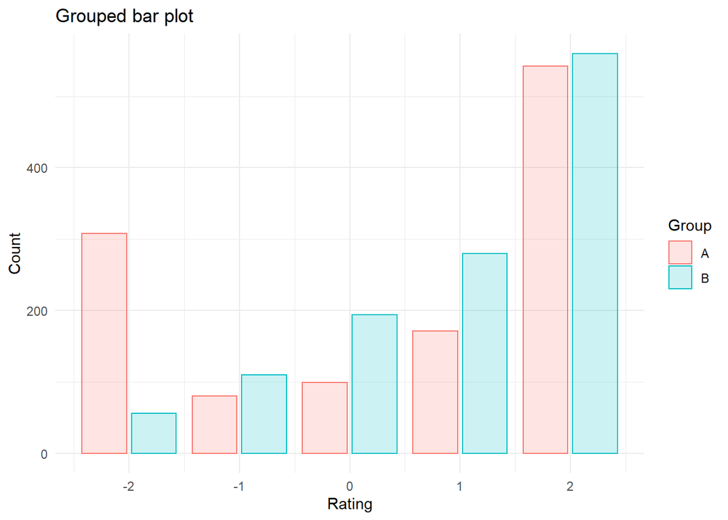

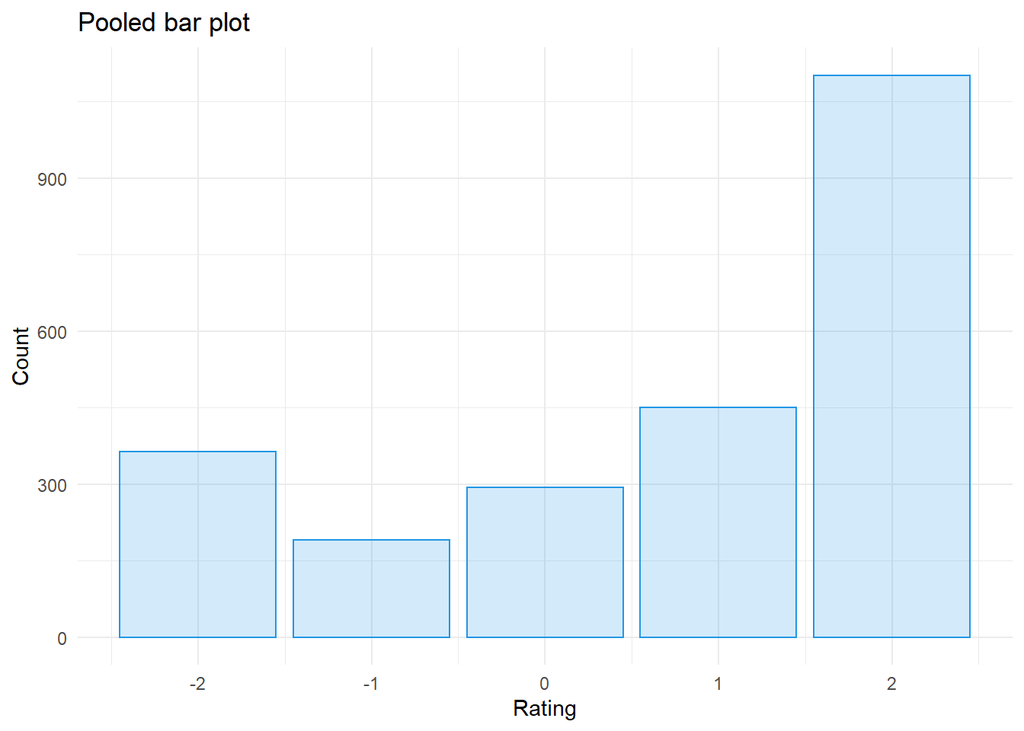

```r
ggplot(d.ratings, aes(x=Rating, fill=Group, color=Group)) +
  geom_bar(stat="count", position=position_dodge2(preserve="single"), alpha=0.2) +
  labs(title="Grouped bar plot", y="Count") + theme_minimal()

ggplot(d.ratings, aes(x=Rating)) +
  geom_bar(stat="count", position=position_dodge2(preserve="single"), alpha=0.2, color=4, fill=4) +
  labs(title="Pooled bar plot", y="Count") + theme_minimal()
```

#### Summary tables and correlation plots

```r
modelString <- "model{
  for (g in 1:Ngrps) {
    b0.mu[g] ~ dnorm(0.0, 1.0E-5) # prior intercept
    b1.mu[g] ~ dnorm(0.0, 1.0E-5) # prior coefficient1
    b2.mu[g] ~ dnorm(0.0, 1.0E-5) # prior coefficient2

    b0.sig[g] ~ dunif(1.0E-4, 100) # prior intercept error
    b1.sig[g] ~ dunif(1.0E-4, 100) # prior coefficient1 error
    b2.sig[g] ~ dunif(1.0E-4, 100) # prior coefficient2 error

    sig[g] ~ dunif(1.0E-5, 100) # prior for the sd

    for (s in 1:Nsubj[g]) {
      b0.s[s, g] ~ dnorm(b0.mu[g], 1/b0.sig[g]^2)
      b1.s[s, g] ~ dnorm(b1.mu[g], 1/b1.sig[g]^2)
      b2.s[s, g] ~ dnorm(b2.mu[g], 1/b2.sig[g]^2)
    }
  }

  for (i in 1:Ntotal) {
    mu[i] <- b0.s[subIdx[i], grpIdx[i]] + b1.s[subIdx[i], grpIdx[i]] * x1[i] + b2.s[subIdx[i], grpIdx[i]] * x2[i]
    y[i] ~ dnorm(mu[i], 1/sig[grpIdx[i]]^2)
  }
}"
writeLines(modelString, con="./models/LinearModel.txt")
```

```r
# Prepare data for JAGS
x1 <- d.ratings$x1
x2 <- d.ratings$x2
y <- d.ratings$Rating
Ntotal <- length(y)
subIdx <- d.ratings$Subject
grpIdx <- as.numeric(as.factor(d.ratings$Group))
Ngrps <- length(unique(d.ratings$Group))
Nsubj <- rep(length(unique(d.ratings$Subject)), times=Ngrps)

dat.linear <- dump.format(list(x1 = x1,
                               x2 = x2,
                               y = y,
                               Ntotal = Ntotal,
                               subIdx = subIdx,
                               grpIdx = grpIdx,
                               Ngrps = Ngrps,
                               Nsubj = Nsubj))

# Let JAGS initialize
inits1 <- dump.format(list(.RNG.name="base::Super-Duper", .RNG.seed=99999 ))
inits2 <- dump.format(list(.RNG.name="base::Wichmann-Hill", .RNG.seed=1234 ))
inits3 <- dump.format(list(.RNG.name="base::Mersenne-Twister", .RNG.seed=6666 ))

monitor <- c("b0.mu", "b1.mu", "b2.mu", "sig")
```

```r
# Run JAGS model
results.linear <- run.jags(model = "./models/LinearModel.txt",
                           monitor = monitor,
                           data = dat.linear,
                           n.chains = n.chains,
                           inits = c(inits1, inits2, inits3),
                           plots = FALSE,
                           burnin = n.burnin,
                           sample = n.sample,
                           thin = n.thin)
```

```
## Compiling rjags model...
## Calling the simulation using the rjags method...
## Adapting the model for 1000 iterations...
## Burning in the model for 1000 iterations...
## Running the model for 4000 iterations...
## Simulation complete
## Calculating summary statistics...
## Calculating the Gelman-Rubin statistic for 8 variables....
## Finished running the simulation
```

```r
knitr::kable(summary(results.linear), align="c", caption="Summary results for the linear model")
```

Summary results for the linear model

|  | Lower95 | Median | Upper95 | Mean | SD | Mode | MCerr | MC%ofSD | SSeff | AC.20 | psrf |
| --- | --- | --- | --- | --- | --- | --- | --- | --- | --- | --- | --- |
| b0.mu[1] | 0.1468833 | 0.2022878 | 0.2648419 | 0.2036940 | 0.0304263 | NA | 0.0018615 | 6.1 | 267 | 0.4123779 | 1.012948 |
| b0.mu[2] | 0.5547507 | 0.6313626 | 0.7090348 | 0.6312211 | 0.0387935 | NA | 0.0006798 | 1.8 | 3256 | 0.0331856 | 1.000511 |
| b1.mu[1] | 0.2959213 | 0.3490125 | 0.4007270 | 0.3489257 | 0.0255967 | NA | 0.0015314 | 6.0 | 279 | 0.3985834 | 1.010361 |
| b1.mu[2] | 0.5389319 | 0.5785500 | 0.6148478 | 0.5785344 | 0.0194529 | NA | 0.0011059 | 5.7 | 309 | 0.3193557 | 1.015693 |
| b2.mu[1] | 0.6075150 | 0.6306419 | 0.6561205 | 0.6305341 | 0.0120744 | NA | 0.0007699 | 6.4 | 246 | 0.4523380 | 1.018678 |
| b2.mu[2] | 0.1799900 | 0.2875940 | 0.3890225 | 0.2875068 | 0.0534959 | NA | 0.0007037 | 1.3 | 5779 | 0.0203211 | 1.000642 |
| sig[1] | 0.8486186 | 0.8833906 | 0.9179941 | 0.8833592 | 0.0179351 | NA | 0.0002499 | 1.4 | 5152 | -0.0115975 | 1.000474 |
| sig[2] | 0.6258526 | 0.6515066 | 0.6793915 | 0.6518467 | 0.0137702 | NA | 0.0001935 | 1.4 | 5062 | 0.0032623 | 1.000765 |

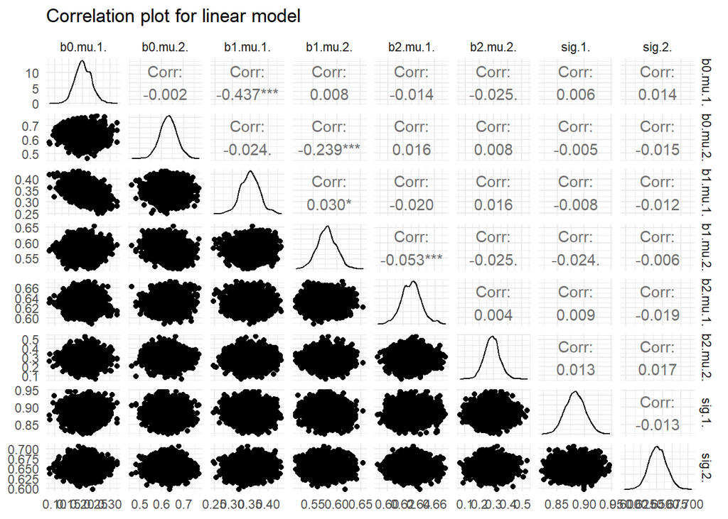

```r
chains.linear <- data.frame(rbind(results.linear[["mcmc"]][[1]],
                                  results.linear[["mcmc"]][[2]],
                                  results.linear[["mcmc"]][[3]]))
ggpairs(chains.linear, title="Correlation plot for linear model") + theme_minimal()
```

```r
# Write in JAGS model
modelString <- "model {
    for (g in 1:Ngrps) {

    for (k in 2:(nYlevels-2)) {
        thresh[k, g] ~ dnorm(k+0.5, 1/2^2)
    }

        b0.mu[g] ~ dnorm(0.0, 1.0E-5) # prior beta0
        b1.mu[g] ~ dnorm(0.0, 1.0E-5) # prior beta1
        b2.mu[g] ~ dnorm(0.0, 1.0E-5) # prior beta2

        b0.sig[g] ~ dunif(1.0E-4, 100) # prior beta0 error
        b1.sig[g] ~ dunif(1.0E-4, 100) # prior beta1 error
        b2.sig[g] ~ dunif(1.0E-4, 100) # prior beta2 error

        sig[g] ~ dunif(nYlevels/1000 , nYlevels*10)

        for (s in 1:Nsubj[g]){
            b0.s[s, g] ~ dnorm(b0.mu[g], 1/(b0.sig[g]^2))
            b1.s[s, g] ~ dnorm(b1.mu[g], 1/(b1.sig[g]^2))
            b2.s[s, g] ~ dnorm(b2.mu[g], 1/(b2.sig[g]^2))
        }
    }

    for (i in 1:Ntotal) {
        mu[i] <- b0.s[subIdx[i], grpIdx[i]] * 1.0   +
             b1.s[subIdx[i], grpIdx[i]] * x1[i] +
             b2.s[subIdx[i], grpIdx[i]] * x2[i]

        pr[i, 1] <- pnorm(thresh[1, grpIdx[i]] , mu[i] , 1/sig[grpIdx[i]]^2)

        for (k in 2:(nYlevels-1)) {
            pr[i, k] <- max(0,  pnorm(thresh[k, grpIdx[i]], mu[i], 1/sig[grpIdx[i]]^2) -
                                                  pnorm(thresh[k-1, grpIdx[i]], mu[i], 1/sig[grpIdx[i]]^2))
        }

        pr[i, nYlevels] <- 1 - pnorm(thresh[nYlevels-1, grpIdx[i]], mu[i], 1/sig[grpIdx[i]]^2)

        y[i] ~ dcat(pr[i,1:nYlevels])
    }
}"

writeLines(modelString, con="./models/OrdinalModel.txt")
```

```r
# Prepare data list for JAGS
x1 <- d.ratings$x1
x2 <- d.ratings$x2
y <- as.numeric(ordered(d.ratings$Rating))
Ntotal <- length(y)
subIdx <- d.ratings$Subject
grpIdx <- as.numeric(as.factor(d.ratings$Group))
Ngrps <- length(unique(d.ratings$Group))
Nsubj <- rep(length(unique(d.ratings$Subject)), times=Ngrps)
nYlevels <- as.numeric(length(unique(d.ratings$Rating)))

thresh = matrix(NA, nrow = nYlevels-1, ncol = 2)
thresh[1, ] <- rep(1.5, 2)
thresh[nYlevels-1, ] <- rep(nYlevels - 0.5, 2)

dat <- dump.format(list(x1=x1,
                        x2=x2,
                        y=y,
                        Ntotal=Ntotal,
                        Ngrps = Ngrps,
                        subIdx = subIdx,
                        grpIdx = grpIdx,
                        Nsubj=Nsubj,
                        nYlevels = nYlevels,
                        thresh = thresh))

# Let JAGS initialize
inits1 <- dump.format(list( .RNG.name="base::Super-Duper", .RNG.seed=99999 ))
inits2 <- dump.format(list( .RNG.name="base::Wichmann-Hill", .RNG.seed=1234 ))
inits3 <- dump.format(list( .RNG.name="base::Mersenne-Twister", .RNG.seed=6666 ))

# Tell JAGS which latent variables to monitor
monitor = c("b0.mu", "b1.mu", "b2.mu", "sig", "thresh")
```

```r
n.sample <- 2000
n.burnin <- 1000
n.thin <- 2
n.chains <- 3

results.ordinal <- run.jags(model = "models/OrdinalModel.txt",
                            monitor = monitor,
                            data = dat,
                            n.chains = 3,
                            inits = c(inits1, inits2, inits3),
                            plots = FALSE,
                            burnin = n.burnin,
                            sample = n.sample,
                            thin = n.thin)
```

```
## Compiling rjags model...
## Calling the simulation using the rjags method...
## Adapting the model for 1000 iterations...
## Burning in the model for 1000 iterations...
## Running the model for 4000 iterations...
## Simulation complete
## Calculating summary statistics...
## Note: The monitored variables 'thresh[1,1]', 'thresh[4,1]',
## 'thresh[1,2]' and 'thresh[4,2]' appear to be non-stochastic; they will
## not be included in the convergence diagnostic
## Calculating the Gelman-Rubin statistic for 16 variables....
## Finished running the simulation
```

```r
knitr::kable(summary(results.ordinal), align="c", digits=6, caption="Summary results for ordinal model")
```

Summary results for ordinal model

|  | Lower95 | Median | Upper95 | Mean | SD | Mode | MCerr | MC%ofSD | SSeff | AC.20 | psrf |
| --- | --- | --- | --- | --- | --- | --- | --- | --- | --- | --- | --- |
| b0.mu[1] | 3.876851 | 3.941098 | 4.010390 | 3.941569 | 0.034154 | NA | 0.001714 | 5.0 | 397 | 0.261224 | 1.007586 |
| b0.mu[2] | 3.716983 | 3.785046 | 3.852849 | 3.784329 | 0.034773 | NA | 0.001648 | 4.7 | 445 | 0.259192 | 1.004263 |
| b1.mu[1] | 0.459217 | 0.545159 | 0.641325 | 0.544780 | 0.046080 | NA | 0.000657 | 1.4 | 4913 | 0.027948 | 0.999962 |
| b1.mu[2] | 0.975382 | 1.056802 | 1.138194 | 1.056810 | 0.042098 | NA | 0.001295 | 3.1 | 1057 | 0.071566 | 1.003824 |
| b2.mu[1] | 1.917548 | 2.081299 | 2.264433 | 2.081591 | 0.088364 | NA | 0.001499 | 1.7 | 3474 | 0.017077 | 1.001048 |
| b2.mu[2] | 0.310054 | 0.493605 | 0.692162 | 0.494325 | 0.096752 | NA | 0.001276 | 1.3 | 5750 | -0.001365 | 1.000741 |
| sig[1] | 0.171358 | 0.202757 | 0.234968 | 0.203255 | 0.016302 | NA | 0.000295 | 1.8 | 3064 | 0.025564 | 1.000388 |
| sig[2] | 0.460416 | 0.500276 | 0.539818 | 0.500781 | 0.020171 | NA | 0.000388 | 1.9 | 2701 | 0.000990 | 1.002139 |
| thresh[1,1] | 1.500000 | 1.500000 | 1.500000 | 1.500000 | 0.000000 | NA | NA | NA | NA | NA | NA |
| thresh[2,1] | 2.349224 | 2.448203 | 2.550956 | 2.446635 | 0.052371 | NA | 0.001123 | 2.1 | 2173 | 0.002828 | 1.000110 |
| thresh[3,1] | 3.343247 | 3.423793 | 3.502723 | 3.423847 | 0.040978 | NA | 0.001299 | 3.2 | 995 | 0.117388 | 1.001930 |
| thresh[4,1] | 4.500000 | 4.500000 | 4.500000 | 4.500000 | 0.000000 | NA | NA | NA | NA | NA | NA |
| thresh[1,2] | 1.500000 | 1.500000 | 1.500000 | 1.500000 | 0.000000 | NA | NA | NA | NA | NA | NA |
| thresh[2,2] | 2.408680 | 2.526917 | 2.636953 | 2.525351 | 0.058944 | NA | 0.001954 | 3.3 | 910 | 0.112729 | 1.005235 |
| thresh[3,2] | 3.440280 | 3.524401 | 3.608588 | 3.523699 | 0.043600 | NA | 0.001544 | 3.5 | 798 | 0.130086 | 1.001759 |
| thresh[4,2] | 4.500000 | 4.500000 | 4.500000 | 4.500000 | 0.000000 | NA | NA | NA | NA | NA | NA |

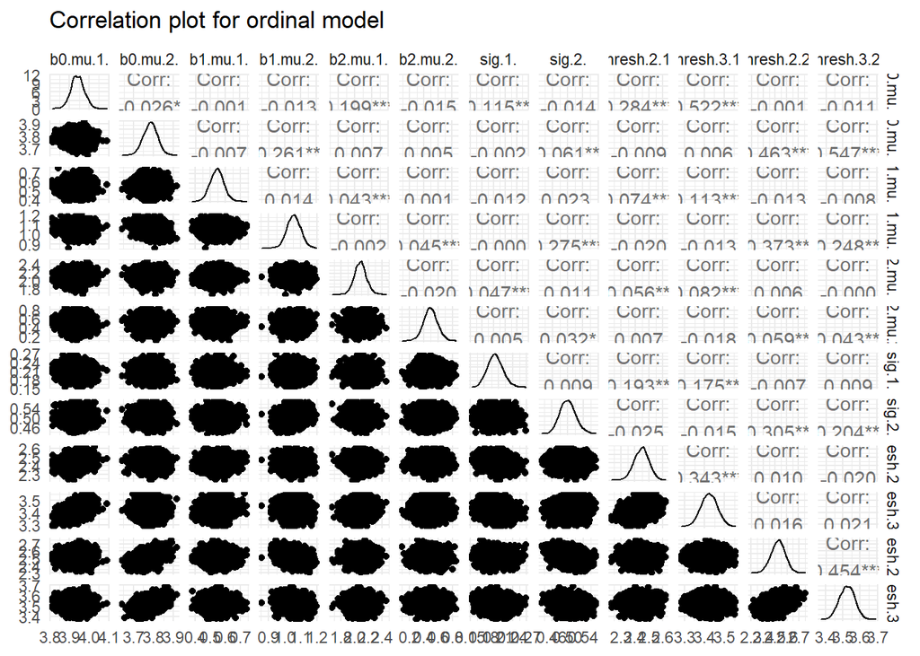

```r
chains.ordinal <- data.frame(rbind(results.ordinal[["mcmc"]][[1]],
                                   results.ordinal[["mcmc"]][[2]],
                                   results.ordinal[["mcmc"]][[3]]))

# Drop the parameters that are not stochastic
ggpairs(chains.ordinal[, c(1:8, 10:11, 14:15)], title="Correlation plot for ordinal model") + theme_minimal()
```

#### Contrasts

Contrasts are constructed based on the difference between sample posterior distributions of parameters:

1. Linear (metric) model
   1. $\mu_{\beta_1}^{A}-\mu_{\beta_2}^{A}$ for group A
   2. $\mu_{\beta_1}^{B}-\mu_{\beta_2}^{B}$ for group B
2. Ordinal model
   1. $\mu_{\beta_1}^{A}-\mu_{\beta_2}^{A}$ for group A
   2. $\mu_{\beta_1}^{B}-\mu_{\beta_2}^{B}$ for group B
3. $\text{Linear }\mu_{\beta_1}^{A} - \text{Ordinal }\mu_{\beta_1}^{A}$
4. $\text{Linear }\mu_{\beta_2}^{A} - \text{Ordinal }\mu_{\beta_2}^{A}$
5. $\text{Linear }\mu_{\beta_1}^{B} - \text{Ordinal }\mu_{\beta_1}^{B}$
6. $\text{Linear }\mu_{\beta_2}^{B} - \text{Ordinal }\mu_{\beta_2}^{B}$
7. $(\text{Linear }\mu_{\beta_1}^{A}-\text{Linear }\mu_{\beta_2}^{A})-(\text{Ordinal }\mu_{\beta_1}^{A}-\text{Ordinal }\mu_{\beta_2}^{A})$
8. $(\text{Linear }\mu_{\beta_1}^{B}-\text{Linear }\mu_{\beta_2}^{B})-(\text{Ordinal }\mu_{\beta_1}^{B}-\text{Ordinal }\mu_{\beta_2}^{B})$

The posterior probability of superiority (PPS) is defined as follows:

$$\text{PPS}=P(\text{contrast}>0)$$

```r
contrast.a1 <- chains.linear[, "b1.mu.1."] - chains.linear[, "b2.mu.1."]
contrast.a2 <- chains.linear[, "b1.mu.2."] - chains.linear[, "b2.mu.2."]

contrast.b1 <- chains.ordinal[, "b1.mu.1."] - chains.ordinal[, "b2.mu.1."]
contrast.b2 <- chains.ordinal[, "b1.mu.2."] - chains.ordinal[, "b2.mu.2."]

contrast.c <- chains.linear[, "b1.mu.1."] - chains.ordinal[, "b1.mu.1."]
contrast.d <- chains.linear[, "b2.mu.1."] - chains.ordinal[, "b2.mu.1."]

contrast.e <- chains.linear[, "b1.mu.2."] - chains.ordinal[, "b1.mu.2."]
contrast.f <- chains.linear[, "b2.mu.2."] - chains.ordinal[, "b2.mu.2."]

contrast.g <- (contrast.a1 - contrast.b1)
contrast.h <- (contrast.a2 - contrast.b2)
```

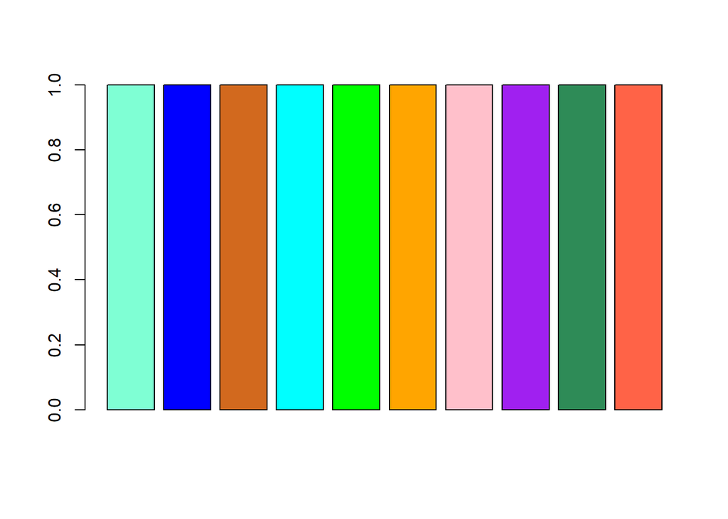

```r
cols <- c("aquamarine", "blue", "chocolate", "cyan", "green", "orange", "pink", "purple", "seagreen", "tomato")
barplot(rep(1, length(cols)), col=cols)
```

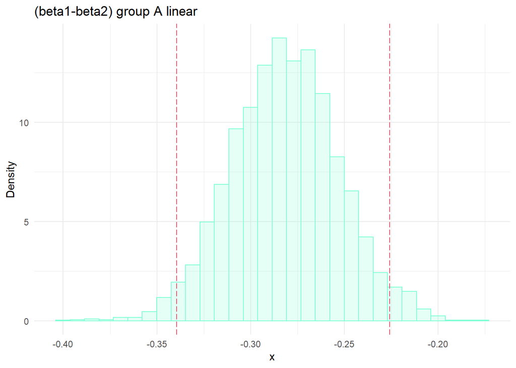

```r
ggplot(data.frame(x=contrast.a1), aes(x=x, y=..density..)) +
  geom_histogram(bins=30, alpha=0.2, color=cols[1], fill=cols[1]) +
  geom_vline(xintercept=hdi(contrast.a1), color=2, lty="longdash") +
  labs(title="(beta1-beta2) group A linear", y="Density") + theme_minimal()
```

```r
## Calculate posterior probability of superiority
pps.contrast.a1 <- mean(contrast.a1 > 0); pps.contrast.a1
```

```
## [1] 0
```

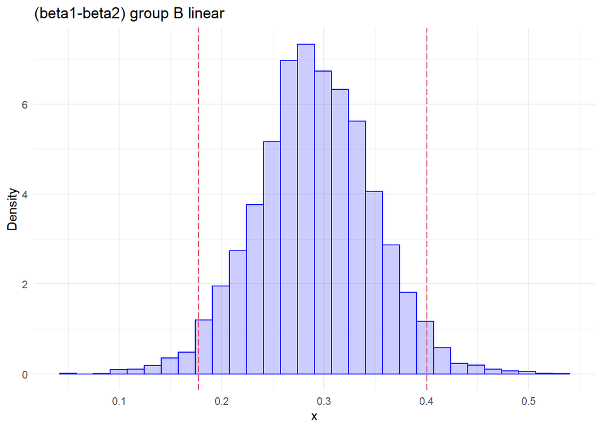

```r
ggplot(data.frame(x=contrast.a2), aes(x=x, y=..density..)) +
  geom_histogram(bins=30, alpha=0.2, color=cols[2], fill=cols[2]) +
  geom_vline(xintercept=hdi(contrast.a2), color=2, lty="longdash") +
  labs(title="(beta1-beta2) group B linear", y="Density") + theme_minimal()
```

```r
## Calculate posterior probability of superiority
pps.contrast.a2 <- mean(contrast.a2 > 0); pps.contrast.a2
```

```
## [1] 1
```

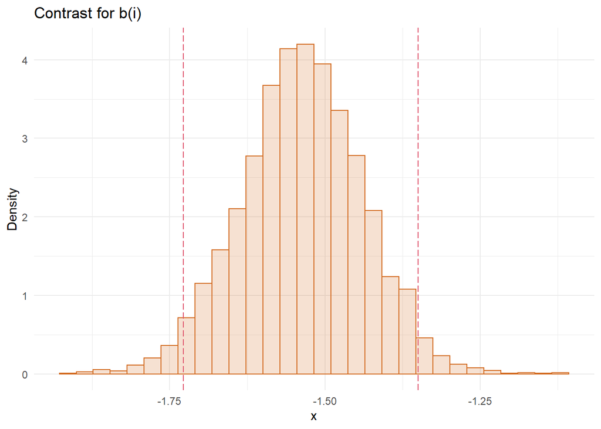

```r
ggplot(data.frame(x=contrast.b1), aes(x=x, y=..density..)) +
  geom_histogram(bins=30, alpha=0.2, color=cols[3], fill=cols[3]) +
  geom_vline(xintercept=hdi(contrast.b1), color=2, lty="longdash") +
  labs(title="Contrast for b(i)", y="Density") + theme_minimal()
```

```r
## Calculate posterior probability of superiority
pps.contrast.b1 <- mean(contrast.b1 > 0); pps.contrast.b1
```

```
## [1] 0
```

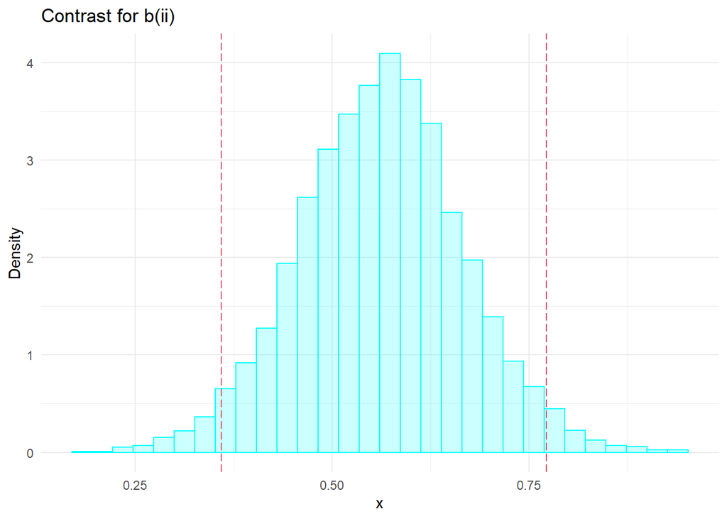

```r
ggplot(data.frame(x=contrast.b2), aes(x=x, y=..density..)) +
  geom_histogram(bins=30, alpha=0.2, color=cols[4], fill=cols[4]) +
  geom_vline(xintercept=hdi(contrast.b2), color=2, lty="longdash") +
  labs(title="Contrast for b(ii)", y="Density") + theme_minimal()
```

```r
## Calculate posterior probability of superiority
pps.contrast.b2 <- mean(contrast.b2 > 0); pps.contrast.b2
```

```
## [1] 1
```

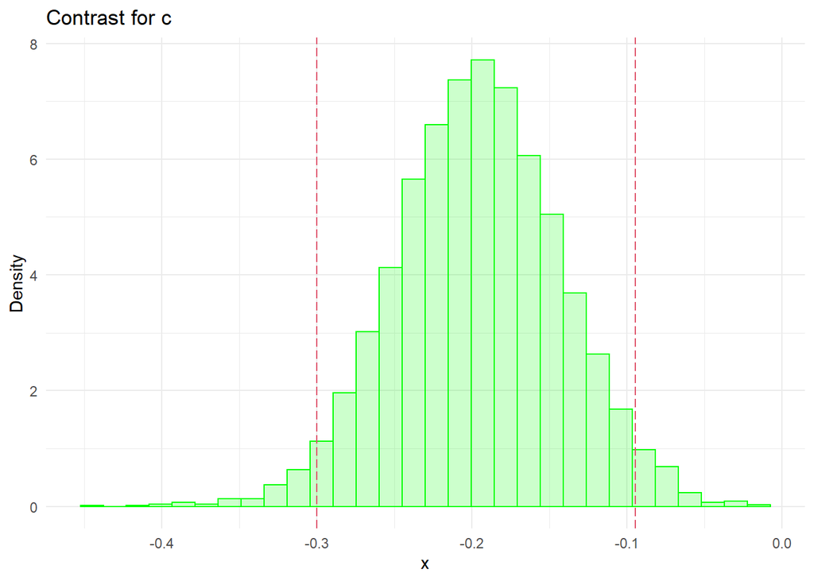

```r
ggplot(data.frame(x=contrast.c), aes(x=x, y=..density..)) +
  geom_histogram(bins=30, alpha=0.2, color=cols[5], fill=cols[5]) +
  geom_vline(xintercept=hdi(contrast.c), color=2, lty="longdash") +
  labs(title="Contrast for c", y="Density") + theme_minimal()
```

```r
## Calculate posterior probability of superiority
pps.contrast.c <- mean(contrast.c > 0); pps.contrast.c
```

```
## [1] 0
```

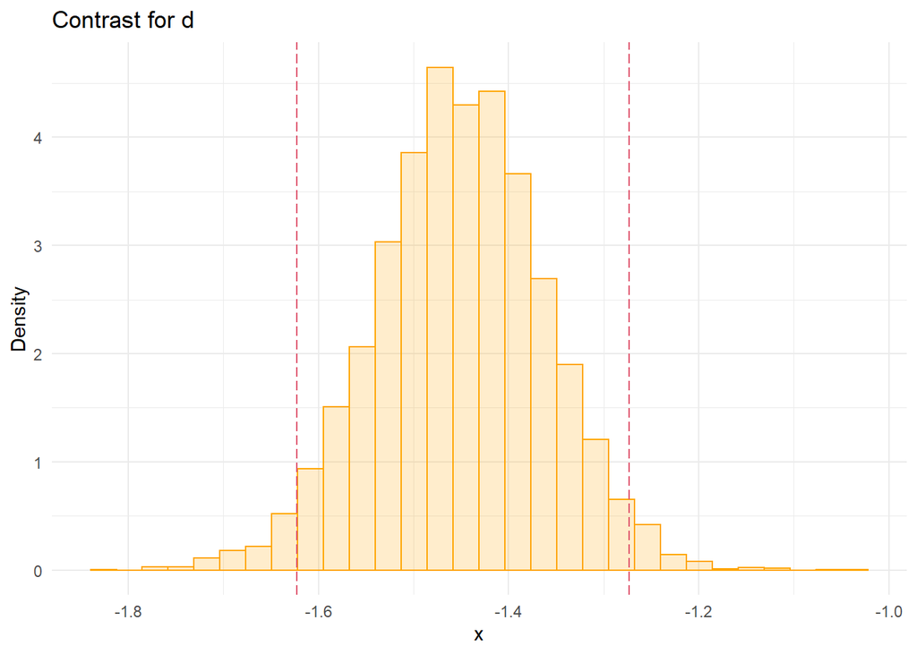

```r
ggplot(data.frame(x=contrast.d), aes(x=x, y=..density..)) +
  geom_histogram(bins=30, alpha=0.2, color=cols[6], fill=cols[6]) +
  geom_vline(xintercept=hdi(contrast.d), color=2, lty="longdash") +
  labs(title="Contrast for d", y="Density") + theme_minimal()
```

```r
## Calculate posterior probability of superiority
pps.contrast.d <- mean(contrast.d > 0); pps.contrast.d
```

```
## [1] 0
```

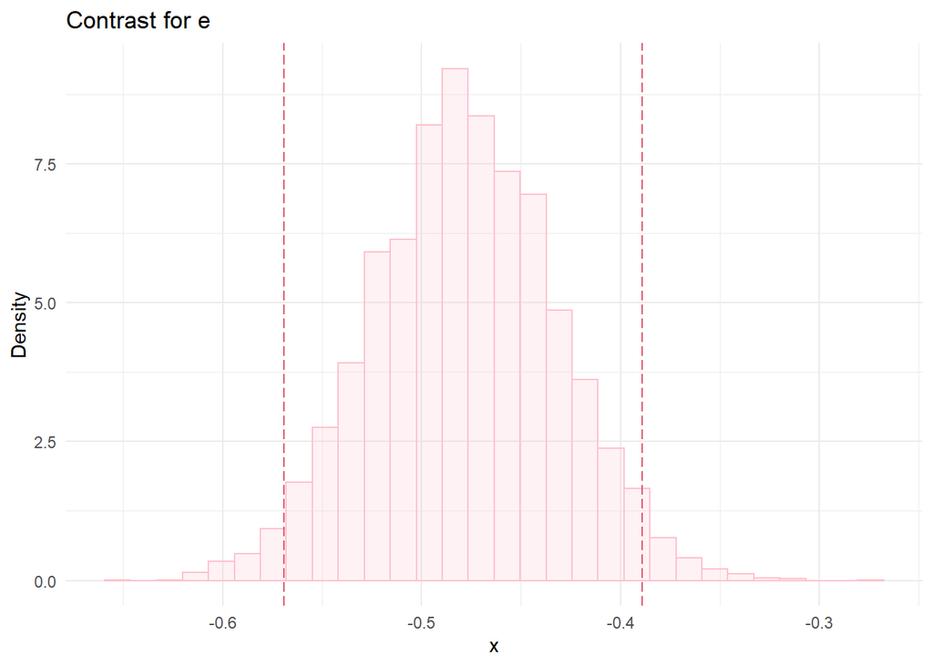

```r
ggplot(data.frame(x=contrast.e), aes(x=x, y=..density..)) +
  geom_histogram(bins=30, alpha=0.2, color=cols[7], fill=cols[7]) +
  geom_vline(xintercept=hdi(contrast.e), color=2, lty="longdash") +
  labs(title="Contrast for e", y="Density") + theme_minimal()
```

```r
## Calculate posterior probability of superiority
pps.contrast.e <- mean(contrast.e > 0); pps.contrast.e
```

```
## [1] 0
```

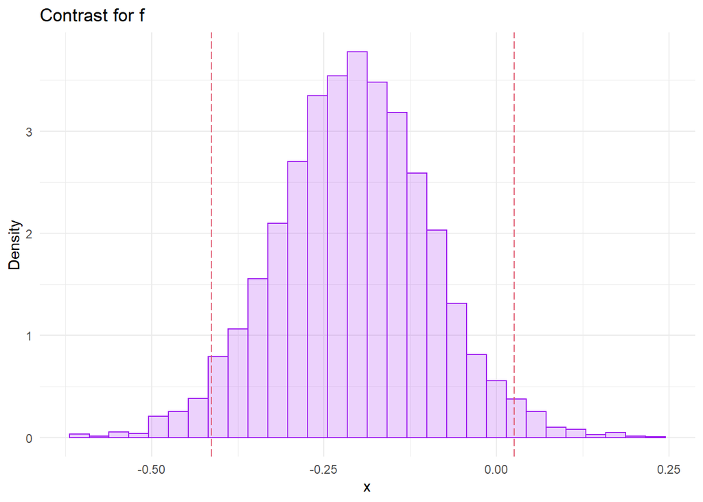

```r
ggplot(data.frame(x=contrast.f), aes(x=x, y=..density..)) +
  geom_histogram(bins=30, alpha=0.2, color=cols[8], fill=cols[8]) +
  geom_vline(xintercept=hdi(contrast.f), color=2, lty="longdash") +
  labs(title="Contrast for f", y="Density") + theme_minimal()
```

```r
## Calculate posterior probability of superiority
pps.contrast.f <- mean(contrast.f > 0); pps.contrast.f
```

```
## [1] 0.03266667
```

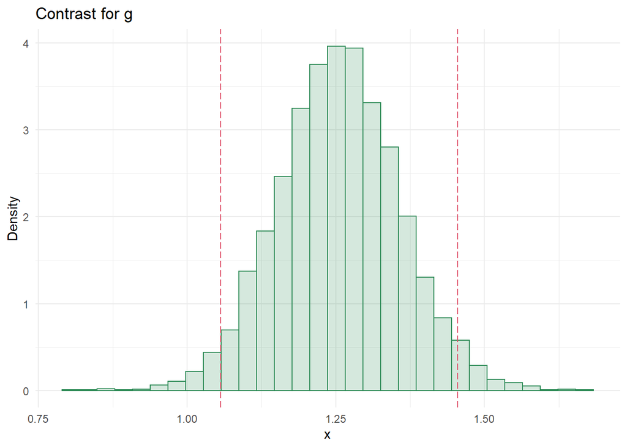

```r
ggplot(data.frame(x=contrast.g), aes(x=x, y=..density..)) +
  geom_histogram(bins=30, alpha=0.2, color=cols[9], fill=cols[9]) +
  geom_vline(xintercept=hdi(contrast.g), color=2, lty="longdash") +
  labs(title="Contrast for g", y="Density") + theme_minimal()
```

```r
## Calculate posterior probability of superiority
pps.contrast.g <- mean(contrast.g > 0); pps.contrast.g
```

```
## [1] 1
```

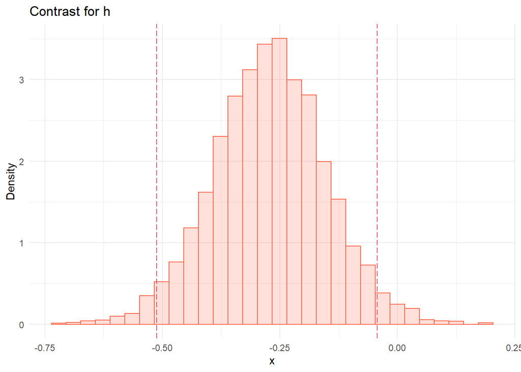

```r
ggplot(data.frame(x=contrast.h), aes(x=x, y=..density..)) +
  geom_histogram(bins=30, alpha=0.2, color=cols[10], fill=cols[10]) +
  geom_vline(xintercept=hdi(contrast.h), color=2, lty="longdash") +
  labs(title="Contrast for h", y="Density") + theme_minimal()
```

```r
## Calculate posterior probability of superiority
pps.contrast.h <- mean(contrast.h > 0); pps.contrast.h
```

```
## [1] 0.01366667
```

```r
pps.summary <- data.frame(
  c(pps.contrast.a1, pps.contrast.a2, pps.contrast.b1, pps.contrast.b2, pps.contrast.c,
    pps.contrast.d, pps.contrast.e, pps.contrast.f, pps.contrast.g, pps.contrast.h)
)
colnames(pps.summary) <- "PPS"
rownames(pps.summary) <- c("Contrast a(i)", "Contrast a(ii)",
                           "Contrast b(i)", "Contrast b(ii)",
                           "Contrast c", "Contrast d",
                           "Contrast e", "Contrast f",
                           "Contrast g", "Contrast h")
knitr::kable(pps.summary, align="c", digits=4)
```

|  | PPS |
| --- | --- |
| Contrast a(i) | 0.0000 |
| Contrast a(ii) | 1.0000 |
| Contrast b(i) | 0.0000 |
| Contrast b(ii) | 1.0000 |
| Contrast c | 0.0000 |
| Contrast d | 0.0000 |
| Contrast e | 0.0000 |
| Contrast f | 0.0327 |
| Contrast g | 1.0000 |
| Contrast h | 0.0137 |